# CMPINF 2130 Summer 2021 - Week 08

reshaping data

Dr. Joseph P. Yurko

July 2021

## Load libraries

```r
library(tidyverse)
```

## Anscombe

```r
anscombe
```

```
##    x1 x2 x3 x4    y1   y2    y3    y4
## 1  10 10 10  8  8.04 9.14  7.46  6.58
## 2   8  8  8  8  6.95 8.14  6.77  5.76
## 3  13 13 13  8  7.58 8.74 12.74  7.71
## 4   9  9  9  8  8.81 8.77  7.11  8.84
## 5  11 11 11  8  8.33 9.26  7.81  8.47
## 6  14 14 14  8  9.96 8.10  8.84  7.04
## 7   6  6  6  8  7.24 6.13  6.08  5.25
## 8   4  4  4 19  4.26 3.10  5.39 12.50
## 9  12 12 12  8 10.84 9.13  8.15  5.56
## 10  7  7  7  8  4.82 7.26  6.42  7.91
## 11  5  5  5  8  5.68 4.74  5.73  6.89
```

The Anscombe data set in base `R` is **not** tidy. Each column name contains 2 pieces of information. We want to separate the column names such that each column is a single entity.

We will need to reshape the data and then manipulate the data to create the tidy and easy to model data set.  
We must **melt** the data into a long format data set. Pandas refers to melting or making a data *molten* when we reshape wide to long. Currently in the `tidyverse` converting from wide to long format is performed with the `pivot_longer()` function.

Before making the data long, I like to include a rowid column. The `cols` argument in `pivot_longer()` is how we instruct what columns “gather” or “make molten”. We can use the `dplyr` select-like terminology to identify those columns.

```r
anscombe %>%
  tibble::rowid_to_column() %>%
  pivot_longer(cols = -rowid)
```

```
## # A tibble: 88 x 3
##    rowid name  value
##    <int> <chr> <dbl>
##  1     1 x1    10
##  2     1 x2    10
##  3     1 x3    10
##  4     1 x4     8
##  5     1 y1     8.04
##  6     1 y2     9.14
##  7     1 y3     7.46
##  8     1 y4     6.58
##  9     2 x1     8
## 10     2 x2     8
## # ... with 78 more rows
```

We can check that we still have the same number of observations per variable with `count()`.

```r
anscombe %>%
  tibble::rowid_to_column() %>%
  pivot_longer(cols = -rowid) %>%
  count(name)
```

```
## # A tibble: 8 x 2
##   name      n
##   <chr> <int>
## 1 x1       11
## 2 x2       11
## 3 x3       11
## 4 x4       11
## 5 y1       11
## 6 y2       11
## 7 y3       11
## 8 y4       11
```

We can provide a character string to identify the columns with the `cols` argument.

```r
anscombe %>%
  tibble::rowid_to_column() %>%
  pivot_longer(cols = !c("rowid"), names_to = "variable_name", values_to = "variable_value")
```

```
## # A tibble: 88 x 3
##    rowid variable_name variable_value
##    <int> <chr>                  <dbl>
##  1     1 x1                     10
##  2     1 x2                     10
##  3     1 x3                     10
##  4     1 x4                      8
##  5     1 y1                      8.04
##  6     1 y2                      9.14
##  7     1 y3                      7.46
##  8     1 y4                      6.58
##  9     2 x1                      8
## 10     2 x2                      8
## # ... with 78 more rows
```

The `tidyr` package has a helper function dedicated to separating character strings based on patterns or positions.

```r
anscombe %>%
  tibble::rowid_to_column() %>%
  pivot_longer(cols = !c("rowid")) %>%
  tidyr::separate(name,
                  c("var_name", "dataset"),
                  sep = 1,
                  remove = FALSE)
```

```
## # A tibble: 88 x 5
##    rowid name  var_name dataset value
##    <int> <chr> <chr>    <chr>   <dbl>
##  1     1 x1    x        1       10
##  2     1 x2    x        2       10
##  3     1 x3    x        3       10
##  4     1 x4    x        4        8
##  5     1 y1    y        1        8.04
##  6     1 y2    y        2        9.14
##  7     1 y3    y        3        7.46
##  8     1 y4    y        4        6.58
##  9     2 x1    x        1        8
## 10     2 x2    x        2        8
## # ... with 78 more rows
```

As a check, the Anscombe data set consists of 4 sub-datasets or groups.

```r
anscombe %>%
  tibble::rowid_to_column() %>%
  pivot_longer(cols = !c("rowid")) %>%
  tidyr::separate(name,
                  c("var_name", "dataset"),
                  sep = 1,
                  remove = TRUE) %>%
  count(dataset, var_name)
```

```
## # A tibble: 8 x 3
##   dataset var_name     n
##   <chr>   <chr>    <int>
## 1 1       x           11
## 2 1       y           11
## 3 2       x           11
## 4 2       y           11
## 5 3       x           11
## 6 3       y           11
## 7 4       x           11
## 8 4       y           11
```

We ultimately want to relate `y` and `x` together. We want to be able to fit linear models with a linear relationship between `y` and `x`.

$$\mathrm{trend_n} = \beta_0 + \beta_1 \times x_n$$

The likelihood is a Gaussian:

$$y_n \mid \mathrm{trend_n}, \sigma \sim \mathrm{normal} \left( \mathrm{trend_n}, \sigma \right)$$

We need to convert the long format into a wide format again. In `tidyverse` this is accomplished via `pivot_wider()`. We must specify the column the new wider columns will be named “from” and the column the new wider values or entries come from.

```r
anscombe %>%
  tibble::rowid_to_column() %>%
  pivot_longer(cols = !c("rowid")) %>%
  tidyr::separate(name,
                  c("var_name", "dataset"),
                  sep = 1,
                  remove = TRUE) %>%
  pivot_wider(names_from = "var_name", values_from = "value")
```

```
## # A tibble: 44 x 4
##    rowid dataset     x     y
##    <int> <chr>   <dbl> <dbl>
##  1     1 1          10  8.04
##  2     1 2          10  9.14
##  3     1 3          10  7.46
##  4     1 4           8  6.58
##  5     2 1           8  6.95
##  6     2 2           8  8.14
##  7     2 3           8  6.77
##  8     2 4           8  5.76
##  9     3 1          13  7.58
## 10     3 2          13  8.74
## # ... with 34 more rows
```

Let’s assign the tidy data set to an object.

```r
ans_tidy <- anscombe %>%
  tibble::rowid_to_column() %>%
  pivot_longer(cols = !c("rowid")) %>%
  tidyr::separate(name,
                  c("var_name", "dataset"),
                  sep = 1,
                  remove = TRUE) %>%
  pivot_wider(names_from = "var_name", values_from = "value")
```

As a check, let’s look at the observations for the first data set.

```r
anscombe %>%
  select(ends_with("1"))
```

```
##    x1    y1
## 1  10  8.04
## 2   8  6.95
## 3  13  7.58
## 4   9  8.81
## 5  11  8.33
## 6  14  9.96
## 7   6  7.24
## 8   4  4.26
## 9  12 10.84
## 10  7  4.82
## 11  5  5.68
```

Out tidy data set associated with Anscombe data set 1:

```r
ans_tidy %>%
  filter(dataset == "1")
```

```
## # A tibble: 11 x 4
##    rowid dataset     x     y
##    <int> <chr>   <dbl> <dbl>
##  1     1 1          10  8.04
##  2     2 1           8  6.95
##  3     3 1          13  7.58
##  4     4 1           9  8.81
##  5     5 1          11  8.33
##  6     6 1          14  9.96
##  7     7 1           6  7.24
##  8     8 1           4  4.26
##  9     9 1          12 10.8
## 10    10 1           7  4.82
## 11    11 1           5  5.68
```

We can easily group and summarize the tidy data. Let’s calculate summary statistics for `x` and `y` associated with each group.

```r
ans_tidy %>%
  group_by(dataset) %>%
  summarise(num_rows = n(),
            avg_x = mean(x),
            var_x = var(x),
            avg_y = mean(y),
            var_y = var(y)) %>%
  ungroup()
```

```
## # A tibble: 4 x 6
##   dataset num_rows avg_x var_x avg_y var_y
##   <chr>      <int> <dbl> <dbl> <dbl> <dbl>
## 1 1             11     9    11  7.50  4.13
## 2 2             11     9    11  7.50  4.13
## 3 3             11     9    11  7.5   4.12
## 4 4             11     9    11  7.50  4.12
```

The basic summary stats of sample averages and sample variances are essentially the same in all 4 Anscome groups. All 4 groups have the same linear relationship regression model! To show that, we will use nesting, functional programming with `purrr` and some help from the `broom` package.

```r
ans_tidy %>%
  group_by(dataset) %>%
  tidyr::nest() %>%
  mutate(lm_mod = purrr::map(data, ~lm(formula = y ~ x, data = .)),
         lm_results = purrr::map(lm_mod, broom::glance),
         lm_coef = purrr::map(lm_mod, broom::tidy))
```

```
## # A tibble: 4 x 5
## # Groups:   dataset [4]
##   dataset data                  lm_mod lm_results            lm_coef
##   <chr>   <list>                <list> <list>                <list>
## 1 1       <tibble[,3] [11 x 3]> <lm>   <tibble[,12] [1 x 12~ <tibble[,5] [2 x 5~
## 2 2       <tibble[,3] [11 x 3]> <lm>   <tibble[,12] [1 x 12~ <tibble[,5] [2 x 5~
## 3 3       <tibble[,3] [11 x 3]> <lm>   <tibble[,12] [1 x 12~ <tibble[,5] [2 x 5~
## 4 4       <tibble[,3] [11 x 3]> <lm>   <tibble[,12] [1 x 12~ <tibble[,5] [2 x 5~
```

Let’s extract coefficients and their standard errors for each for 4 fit models.

```r
ans_tidy %>%
  group_by(dataset) %>%
  tidyr::nest() %>%
  mutate(lm_mod = purrr::map(data, ~lm(formula = y ~ x, data = .)),
         lm_results = purrr::map(lm_mod, broom::glance),
         lm_coef = purrr::map(lm_mod, broom::tidy)) %>%
  select(dataset, lm_coef) %>%
  tidyr::unnest(lm_coef)
```

```
## # A tibble: 8 x 6
## # Groups:   dataset [4]
##   dataset term        estimate std.error statistic p.value
##   <chr>   <chr>          <dbl>     <dbl>     <dbl>   <dbl>
## 1 1       (Intercept)    3.00      1.12       2.67 0.0257
## 2 1       x              0.500     0.118      4.24 0.00217
## 3 2       (Intercept)    3.00      1.13       2.67 0.0258
## 4 2       x              0.5       0.118      4.24 0.00218
## 5 3       (Intercept)    3.00      1.12       2.67 0.0256
## 6 3       x              0.500     0.118      4.24 0.00218
## 7 4       (Intercept)    3.00      1.12       2.67 0.0256
## 8 4       x              0.500     0.118      4.24 0.00216
```

Let’s reshape into a wide format and look at the estimates for the intercept and slope across the 4 data sets.

```r
ans_tidy %>%
  group_by(dataset) %>%
  tidyr::nest() %>%
  mutate(lm_mod = purrr::map(data, ~lm(formula = y ~ x, data = .)),
         lm_results = purrr::map(lm_mod, broom::glance),
         lm_coef = purrr::map(lm_mod, broom::tidy)) %>%
  select(dataset, lm_coef) %>%
  tidyr::unnest(lm_coef) %>%
  select(dataset, term, estimate) %>%
  pivot_wider(names_from = 'term', values_from = 'estimate')
```

```
## # A tibble: 4 x 3
## # Groups:   dataset [4]
##   dataset `(Intercept)`     x
##   <chr>           <dbl> <dbl>
## 1 1                3.00 0.500
## 2 2                3.00 0.5
## 3 3                3.00 0.500
## 4 4                3.00 0.500
```

Let’s now look at the performance metrics.

```r
ans_tidy %>%
  group_by(dataset) %>%
  tidyr::nest() %>%
  mutate(lm_mod = purrr::map(data, ~lm(formula = y ~ x, data = .)),
         lm_results = purrr::map(lm_mod, broom::glance),
         lm_coef = purrr::map(lm_mod, broom::tidy)) %>%
  select(dataset, lm_results) %>%
  tidyr::unnest(lm_results)
```

```
## # A tibble: 4 x 13
## # Groups:   dataset [4]
##   dataset r.squared adj.r.squared sigma statistic p.value    df logLik   AIC
##   <chr>       <dbl>         <dbl> <dbl>     <dbl>   <dbl> <dbl>  <dbl> <dbl>
## 1 1           0.667         0.629  1.24      18.0 0.00217     1  -16.8  39.7
## 2 2           0.666         0.629  1.24      18.0 0.00218     1  -16.8  39.7
## 3 3           0.666         0.629  1.24      18.0 0.00218     1  -16.8  39.7
## 4 4           0.667         0.630  1.24      18.0 0.00216     1  -16.8  39.7
## # ... with 4 more variables: BIC <dbl>, deviance <dbl>, df.residual <int>,
## #   nobs <int>
```

Let’s now look at the data. We will use a scatter plot and facet by the data set.

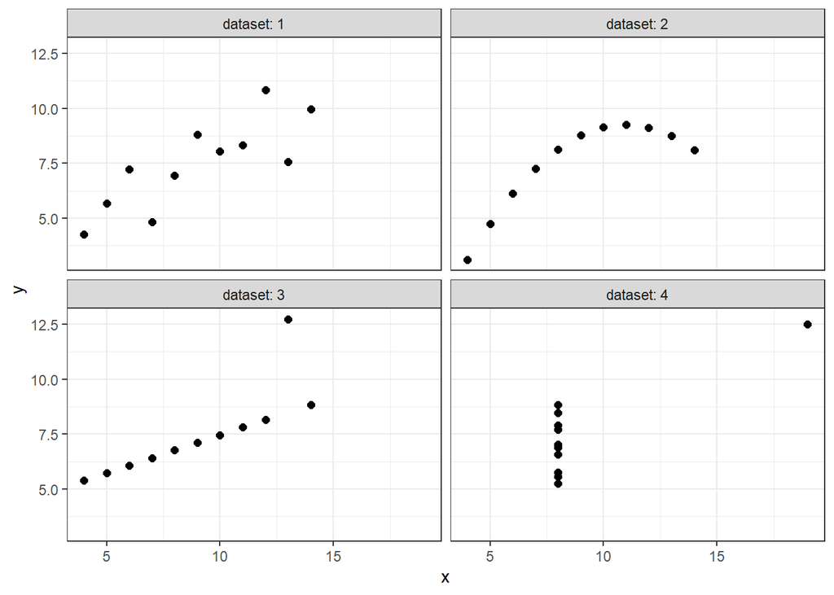

```r
ans_tidy %>%
  ggplot(mapping = aes(x = x, y = y)) +
  geom_point(size = 2) +
  facet_wrap(~dataset, labeller = "label_both") +
  theme_bw()
```

We can include the linear relationship linear model on the facets that we had previously fit.

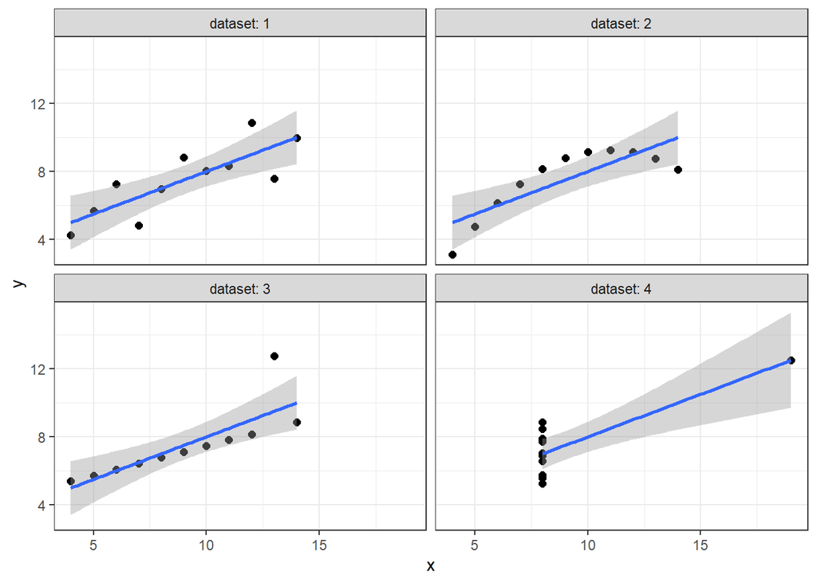

```r
ans_tidy %>%
  ggplot(mapping = aes(x = x, y = y)) +
  geom_point(size = 2) +
  geom_smooth(formula = y ~ x,
              method = lm) +
  facet_wrap(~dataset, labeller = "label_both") +
  theme_bw()
```